# Vagrant Lab 1

# Vagrant Lab 1

Let's Deploy a Virtual Machine with Vagrant| Bert Tejeda |

## Forward

Thank you for taking interest in this interactive document.

If you're on the Windows platform, you'll likely be accessing this file in its **.HTA** format, which provides a superior experience for interaction with your workstation or laptop.

You can also output the resulting document as a **.html** file, which will allow you to open it in a web browser, but some caveats before you do that:

- If opening the document in a browser other than Internet Explorer, the shell interaction will **not** work at all
- If using Internet Explorer to open the .html file, should you choose to go that route, you'll need to allow ActiveX controls once prompted

Moving on.

## How to Use this Document

Notice the navigation bar at the top.

There are several buttons, one of which reads Sidebar

Clicking it will reveal a navigation menu on the left. That's pretty much all you need to know to get around this document.

If you're on Windows and you're running this as .HTA or via Internet Explorer, you can utilize the command buttons up top for launching system processes, e.g. Install Lab Requirements

## What This Lab Covers

Here's what I will cover for Lab 1 of this Vagrant tutorial series:

- What is vagrant?
- How to install Vagrant on Windows/Linux/MacOS
- How to prepare a test environment for using Vagrant

Let's begin with the first topic: What is vagrant?

**NOTE**: You must have chocolatey installed before proceeding!

- Mark All For Installation
- Install cmder
- Install Sublime Text 3
- Install Virtualbox
- Install Vagrant

## What is Vagrant?

- [Vagrant](https://www.vagrantup.com/) is an open-source software product for building and maintaining portable virtual software development environments:
- Aims to simplify configuration management of virtualizations in order to increase development productivity
- Written in the Ruby programming language, and is thus highly extensible
- Supports numerous hypervisor [providers](https://www.vagrantup.com/docs/providers/), for example:
  - [VirtualBox](https://www.vagrantup.com/docs/virtualbox/)
  - [Hyper-V](https://www.vagrantup.com/docs/hyperv/)
  - [VMware](https://www.vagrantup.com/docs/vmware/)
  - [KVM/libvirt](https://github.com/vagrant-libvirt/vagrant-libvirt)
- It is a commandline tool
- Under the hood, it's just sending commands to the corresponding [hypervisor](https://www.reddit.com/r/explainlikeimfive/comments/l16v7/eli5_hypervisor/)

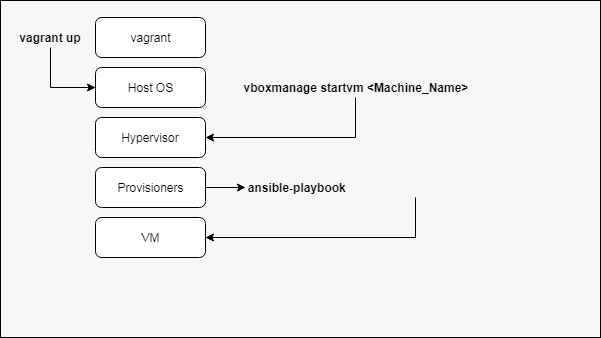

Vagrant 'talking' to Virtualbox

Think of it like this:

Vagrant is to **Virtual Machines** what [Docker](https://www.reddit.com/r/sysadmin/comments/33uts6/eli5_docker_what_exactly_is_it_what_does_it_do/) is to **Containers**

### Terminology

Throughout the sections ahead, I'll make reference to the following terms:

- [box](https://www.vagrantup.com/docs/boxes.html) - This is vagrant terminology for *base image* A box is similar to a **.vmdk** file in **vmware**  
  In fact, you can convert a **.vmdk** file to vagrant **.box** format using [qemu-img convert](https://docs.openstack.org/image-guide/convert-images.html)  
  The process is rather involved, and is essentially a conversion from **.vmdk** => **.qcow2** => **.box**
- **machine**: [Virtual machine](https://www.reddit.com/r/explainlikeimfive/comments/1a86vh/eli5_what_is_a_virtual_machine_how_does_it_work/)

### Installation

If you're on Windows and have activated this document as a .hta or via Internet Explorer (with Active X Controls allowed),  
just click the Install Lab Requirements button above to get started with the requirements.  
It's rather experimental and may not work, so be warned!

If that doesn't work or you're not on Windows/IE, you can opt to install vagrant **manually**, as follows:

1. Navigate to the vagrant downloads site: [vagrant downloads](https://www.vagrantup.com/downloads.html)
2. Once downloaded, launch the installer and follow the prompts
- The installer will make the `vagrant` command available to your command-line terminal via your *PATH* variable
- If upon installation, the `vagrant` command is not found, you may need to restart whatever terminal you have open, e.g. cmd, bash, iterm2, cygwin, etc

I **highly** recommend you install the following applications along with **vagrant**: - [cmder](http://cmder.net/)  
The commandline experience presented through it more closely matches a posix-compliant operating environment - [Sublime Text 3](https://www.sublimetext.com/3)  
Forget Notepad++, just throw it away. This one is king!

Once you've installed the tools, proceed to the next section: Preparing Your Lab

## Lab Prep

To follow along, you'll need the following:

1. [vagrant](https://www.vagrantup.com/downloads.html)
2. [virtualbox](https://www.virtualbox.org/)

Again, some notes:

- The Install Lab Requirements button above is experimental and may not work, but you can give it a try (only if you're on Windows).  
  You'll be presented with an installation menu from which you can choose to install vagrant, among other tools.
- **All** of my testing is being done from a [cmder](http://cmder.net/) bash terminal, so if you want to follow along, I suggest you install that tool.

Once you've met all requirements, we can proceed in preparing your local lab environment.

Moving along ☞

## Initializing virtual machines using vagrant

1. Again, you'll need the **vagrant** command installed to follow along, so make sure you've obtained the requisite programs.
2. From your terminal, create a new directory under ~/git/vagrant:
   - `mkdir -p ~/git/vagrant`
   - `cd ~/git/vagrant`
3. Initialize a vagrant project based on the Ubuntu Xenial x64 box (a.k.a. VM Template)
   - `vagrant init -m ubuntu/xenial64`  
     The vagrant command will notify you once it's done  
     It will have created a file named *Vagrantfile* in the current directory  
     This is the file that *defines* your Virtual Machine (VM)
4. Review the status of the virtual machine
   - `vagrant status`  
     You should see something similar to:

[figure not shown]

5. Now that you are aware of the available machines, let's boot up the **default** host:
   - `vagrant up default`  
     You should see something similar to:

[figure not shown]

6. You'll observe that vagrant takes the following actions:
   - Checks for the **machine** **box** as specified in the **Vagrantfile**
   - Downloads the **box** locally if necessary  
     i.e., if the box has already been downloaded, vagrant will happily use the cached version
   - Boots up the **machine** using the **box** image
   - Checks if the initial **provisioning** tasks have been run against the **machine**,  
     and if not, will run the initial provisionment task(s)
7. Again, vagrant is simply 'talking' to the underlying hypervisor and cycling through several phases of the machine boot up process, as illustrated:

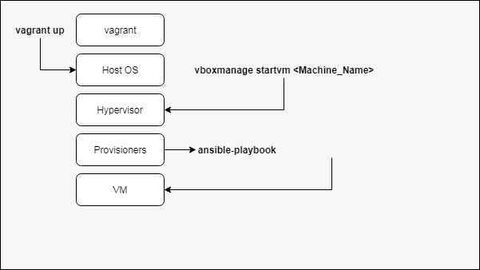

8. If you launch Virtual Box, you'll see your Virtual Machine in the list of VMs:

[figure not shown]

## Accessing your machines using vagrant

The machine *default* should be booted and ready for action 😎

You can now `ssh` into the machine and play around the terminal:

`vagrant ssh default`

I encourage you to read through the [vagrant documentation](https://www.vagrantup.com/docs/) for in-depth information.

## This concludes lab1.

In lab2, we'll be creating a Windows-Based Virtual Machine!

Lab2 will cover:

- Creating Windows-Based Vagrant Boxes using [packer](https://www.packer.io/intro/getting-started/vagrant.html)
- Bootstrapping the Windows VM using the [vagrant provision](https://www.vagrantup.com/docs/cli/provision.html) command
- Interacting with your Windows VM